# Fit the sinusoidal amplitudes

First load the fit classes.

```python
import ROOT
ROOT.gROOT.ProcessLine(".x $BRUFIT/macros/LoadBru.C")
#%jsroot
```

```
Welcome to JupyROOT 6.16/00
```

```
0L
```

Now load and compile the PhiAsymmetry PDF class you created.

```python
ROOT.Loader.Compile("PhiAsymmetry.cxx");
```

Use an instance of the FitManager class to organise the fit and give it an ouput directory.

```python
fm = ROOT.FitManager()
fm.SetUp().SetOutDir("outObs1/");
```

Now load the experimentally measured variables (or observables). I must use the name of the variables in the tree.

Note the slighlty different notation for the Category PolState. If any events had a PolState of 0 for example, then they would not be included in the fit.

```python
fm.SetUp().LoadVariable("Phi[-180,180]");
fm.SetUp().LoadVariable("Pol[0,1]");
fm.SetUp().LoadCategory("PolState[Polp=1,Polm=-1]");
```

If I want to use any other variable, or example to apply a cut, I must load it as an AuxVar. The limits given will be applied to the datset. Here we will not apply it, but it is left commented out to show what you could do.

```python
#fm.SetUp().LoadAuxVar("M1[0,10]"); //Load Aux Var, limits used as cut
#fm.SetUp().AddCut("M1>2"); //Additional cut based on vars or aux vars
```

IMPORTANT here we set the event ID variable. Each event in your tree should have a unique id with which to synchronise with weights. This is useful as it allows us to break the data up, perform seperate fits then combine the weights afterwards. The weights are not written into the input tree, rather they are stored seperately (as HS::Weights) and combined when required. This allows you to use various sets of weights when performing fits or regenerate the weights after some corrections etc.

```python
fm.SetUp().SetIDBranchName("fgID");
```

Create and load into the fit manager my PDF class. The class is callled PhiAsymmetry, this object is given the name SigAsym, which can be used to assign simulated data later. Here I explicitly declare my fit parameters A and B with there initial values and ranges. Phi, Pol and PolState all match the variables loaded above.

```python
fm.SetUp().FactoryPDF("PhiAsymmetry::SigAsym( Phi,Pol,PolState,A[0,-1,1],B[0,-1,1] )");
fm.SetUp().LoadSpeciesPDF("SigAsym",1);
```

Now I load my data, here I will use both data to fit and MC data for the integral calculation. Note in the latter case the string "SigAsym" matches the name given to the PDF object above. In principal I could fit multiple PDFs and give them each different MC data.

The strings are treename, filename and PDF name (simulation only).

```python
fm.LoadData("MyModel","Data.root");
fm.LoadSimulated("MyModel","MC.root","SigAsym");
```

```
DataEvents::Load MyModel with 1 files
```

Now I attach the weights from my sPlot fit. I want to use the signal weights which were given the name "Signal" in the sPlot notebook.

Also there are two possible sets of weights from using a Gaussian or simulated PDF. You can switch between either here.

```python
fm.Data().LoadWeights("Signal","outSplot/Tweights.root");
#fm.Data().LoadWeights("Signal","outSplotSim/Tweights.root"); #use weights from simulated PDF
```

```
Weights HSsWeights contains 100000 events associated file is
ID branch name : fgID
Species are :
BG
Signal
The first ten entries are :
0 0.160932 0.839068
1 -0.147928 1.14793
2 1.15202 -0.15202
3 1.43807 -0.438065
4 1.42256 -0.422553
5 -0.008293 1.00829
6 1.4532 -0.453194
7 1.44715 -0.447147
8 0.399246 0.600753
9 1.44954 -0.449542
  DataEvents::LoadWeights using Signal weights /work/Dropbox/HaSpect/dev/brufit/tutorials/WeightedObervable/outSplot/Tweights.root HSsWeights
```

Now run the fits. I use the Process classes which allow me to choose between running directly here on a single core or multicore via PROOF-lite. It doesn't make sense to run with PROOF unless multiple splits have been defined with LoadBinVar or you are using Bootstrap, in which case you should relate the number of cores requested to the number of splits or bootstraps

```
 RooAbsData& DataEvents::Get  /work/Dropbox/HaSpect/dev/brufit/tutorials/WeightedObervable/Data.root tree MyModel weights 0x5622d3a79ee0 Signal
FiledTree::~FiledTree()  tree name MyModel 100000 /work/Dropbox/HaSpect/dev/brufit/tutorials/WeightedObervable/Data.root
[#1] INFO:DataHandling -- RooAbsCategory::attachToTree(PolState) TTree branch PolState will be interpreted as category index
FiledTree::~FiledTree()  tree name MyModel 100000 /work/Dropbox/HaSpect/dev/brufit/tutorials/WeightedObervable/outObs1///DataInWeightedTree0.root
RooDataSet::DataEvents[Phi,Pol,PolState,fgID,weight:Signal] = 100000 entries (50038.5 weighted)
RooHSEventsPDF::SetEvTree SigAsym
RooHSEventsPDF::SetEvTree Ammended cut (PolState==1||PolState==-1)
RooHSEventsPDF::SetEvTree Ammended cut
RooHSEventsPDF::SetEvTree SigAsym 1000000
RooHSEventsPDF::AddProtoData 0x5622d622cea0 0x5622d61d6a20
[#1] INFO:Minization -- RooMinimizer::optimizeConst: activating const optimization
[#1] INFO:Minization --  The following expressions will be evaluated in cache-and-track mode: (SigAsym)
Minuit2Minimizer: Minimize with max-calls 1500 convergence for edm < 1 strategy 1
MnSeedGenerator: for initial parameters FCN = -491405.0695285
MnSeedGenerator: Initial state:   - FCN =  -491405.0695285 Edm =      3671.66 NCalls =     15
VariableMetric: start iterating until Edm is < 0.001
VariableMetric: Initial state   - FCN =  -491405.0695285 Edm =      3671.66 NCalls =     15
VariableMetric: Iteration #   0 - FCN =  -491405.0695285 Edm =      3671.66 NCalls =     15
VariableMetric: Iteration #   1 - FCN =  -495250.2053212 Edm =      11.7257 NCalls =     22
VariableMetric: Iteration #   2 - FCN =  -495262.8701391 Edm =     0.145202 NCalls =     29
VariableMetric: Iteration #   3 - FCN =  -495263.0403187 Edm =  3.44432e-05 NCalls =     37
VariableMetric: After Hessian   - FCN =  -495263.0403187 Edm =  2.87747e-05 NCalls =     57
VariableMetric: Iteration #   4 - FCN =  -495263.0403187 Edm =  2.87747e-05 NCalls =     57
Minuit2Minimizer : Valid minimum - status = 0
FVAL  = -495263.040318718064
Edm   = 2.87747332917962649e-05
Nfcn  = 57
A	  = 0.397155	 +/-  0.00763702	(limited)
B	  = -0.589918	 +/-  0.00728311	(limited)
Yld_SigAsym	  = 50038.8	 +/-  223.691	(limited)
[#1] INFO:Fitting -- RooAbsPdf::fitTo(TotalPDF) Calculating sum-of-weights-squared correction matrix for covariance matrix
[#1] INFO:Minization -- RooMinimizer::optimizeConst: deactivating const optimization

  RooFitResult: minimized FCN value: -495263, estimated distance to minimum: 49945.6
                covariance matrix quality: Unknown, matrix was externally provided
                Status : MINIMIZE=0 HESSE=0 HESSE=0

    Floating Parameter    FinalValue +/-  Error
  --------------------  --------------------------
                     A    3.9715e-01 +/-  3.18e-02
                     B   -5.8992e-01 +/-  3.01e-02
           Yld_SigAsym    5.0039e+04 +/-  8.22e+02

PlotResults::PlotResults 0x5622d630c650 0x5622cf27ce40
model 0x5622d442d440
[#1] INFO:Plotting -- RooAbsPdf::plotOn(TotalPDF) directly selected PDF components: (SigAsym)
[#1] INFO:Plotting -- RooAbsPdf::plotOn(TotalPDF) indirectly selected PDF components: ()
[#1] INFO:Plotting -- RooAbsReal::plotOn(TotalPDF) plot on Phi integrates over variables (Pol,PolState)
RooHSEventsPDF::HistIntegrals
[#1] INFO:Plotting -- RooAbsReal::plotOn(TotalPDF) plot on Phi integrates over variables (Pol,PolState)
[#1] INFO:Plotting -- RooAbsPdf::plotOn(TotalPDF) directly selected PDF components: (SigAsym)
[#1] INFO:Plotting -- RooAbsPdf::plotOn(TotalPDF) indirectly selected PDF components: ()
[#1] INFO:Plotting -- RooAbsReal::plotOn(TotalPDF) plot on Pol integrates over variables (Phi,PolState)
[#1] INFO:Plotting -- RooAbsReal::plotOn(TotalPDF) plot on Pol integrates over variables (Phi,PolState)
RooArgList:: = (A,B)
RooArgList:: = (Yld_SigAsym)
FiledTree::~FiledTree()  tree name MyModel 0 /work/Dropbox/HaSpect/dev/brufit/tutorials/WeightedObervable/MC.root
```

[output not shown]

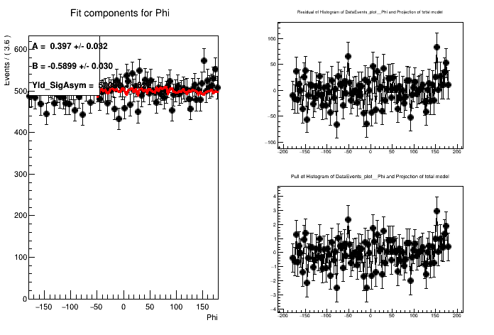

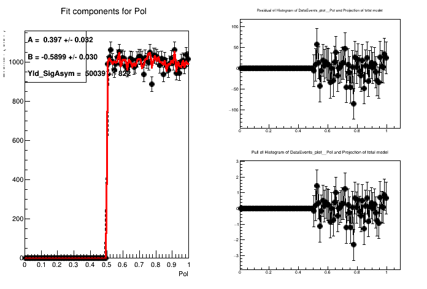

```python
ROOT.Here.Go(fm)
```

All plots and fit parameters will be saved into the output directory Results.root file. If LoadBinVar splits were applied then they will be in directories related to the bin name.

If the plot does not appear you can try removing the %jsroot in the first cell. Unfortunately this will mean the histograms will not be interactive.